# Einführung in die Vergleichende Politikwissenschaft

Autor:in

Philip Manow und Armin Schäfer

Veröffentlichungsdatum

16.07.2024

# Vorwort

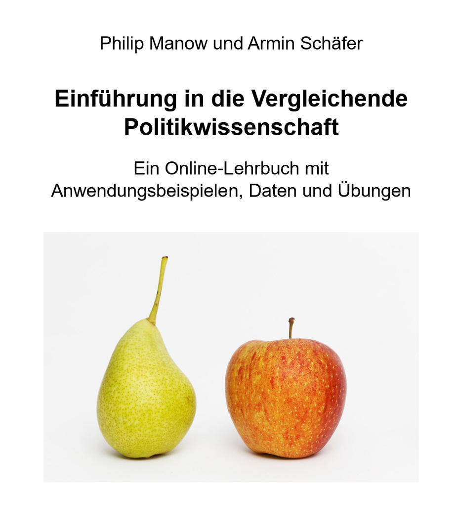

Mit diesem Lehrbuch zielen wir auf eine komplette Neuausrichtung der einführenden Lehre in die Vergleichende Politikwissenschaft auf BA-Niveau. Geplant ist ein gemeinsam konzipiertes Open source, open access-Lehrbuch (auf der Grundlage von R und Quarto) mit vielfältigen, auf thematisch spezifischen Datensätzen basierenden Übungseinheiten. Dies würde eine aktuelle, den jeweiligen Forschungsstand widerspiegelnde, dabei die Studierenden mit vielen interaktiven Elementen und auf der Grundlage jeweils aktueller Daten auch methodisch an die Forschungspraxis heranführende Lehre ermöglichen. Das Lehrbuch wäre frei zugänglich und für andere Teilbereiche der Politikwissenschaft anpassbar, könnte fortlaufend durch die Studierenden evaluiert und unter Einbindung der Hochschuldidaktik in Bremen und Mainz fortentwickelt werden. Es könnte in PDF-, HTML- oder EPUB-Formaten angeboten werden. Wir haben mehrjährige Erfahrungen mit Einführungsveranstaltungen an verschiedenen Universitäten (Bremen, Münster, Mainz) gesammelt, und unabhängig voneinander die Lehre auf der Basis der frei zugänglichen Datenanalyse- und Statistiksoftware *R*, mit ihren zusätzlichen Präsentations- und Visualisierungspaketen umgestellt. Mit der Konzeption eines neuen Lehrbuchs wollen wir den Studierenden eine intensive Auseinandersetzung mit aktuellen Themen der Vergleichenden Politikwissenschaft (Krise der Demokratie, Konstitutionalisierung der Politik) ermöglichen, die gleichzeitig eine Anleitung zur eigenen Forschung ist.